# Analysis of survival data for Ewing sarcoma

I again want to look at survival data for Ewing sarcoma, but instead of just going set by set, I am going to combine all the sets I can find into one object and go from there. I have performed the preprocessing of the data, and now will combine and do survival analysis.

## Setting up the environment

These are packages you will need for this notebook. For exact versions used, please refer to the session info at the bottom of this notebook.

I want to set a base directory that we can use as a link to the directory where we will do most of the work. I use two directories here because the Workspace is what is pushed to GitHub and contains scripts and plot files, but the Repository is where more of the big data is stored that does not get pushed.

```r
generalDatasets = 'C:/Users/chris/OneDrive/Documents/bccrc/projectsRepository/generalDatasets'
baseWorkspace = 'C:/Users/chris/OneDrive/Documents/bccrc/projectsWorkspace/sorensenLab/relatedToYbx1'
baseRepository = 'C:/Users/chris/OneDrive/Documents/bccrc/projectsRepository/sorensenLab/relatedToYbx1'
```

We need to call a source file that has some functions we will need. For simplicity and ease of tracking, I make a copy of this file in each directory that I will work in in order to be able to trace the exact one functions that are used, in case I change them and mistakenly don’t push it to GitHub.

```r
source(paste(baseWorkspace, '/microarray20200604_ewingSarcomaAllSets/userDefinedFunctions.R', sep = ''))
```

## Data processing

First we will read in all the data sets.

```r
##########################################################################################
savolaExpression = readRDS(paste(baseRepository, '/microarray20200604_ewingSarcomaAllSets/dataset_savolaExpression.rds', sep = ''))
savolaPhenotype = readRDS(paste(baseRepository, '/microarray20200604_ewingSarcomaAllSets/dataset_savolaPhenotype.rds', sep = ''))
volchenExpressionA = readRDS(paste(baseRepository, '/microarray20200604_ewingSarcomaAllSets/dataset_volchenboumExpressionSetA.rds', sep = ''))
volchenPhenotypeA = readRDS(paste(baseRepository, '/microarray20200604_ewingSarcomaAllSets/dataset_volchenboumPhenotypeSetA.rds', sep = ''))
volchenExpressionB = readRDS(paste(baseRepository, '/microarray20200604_ewingSarcomaAllSets/dataset_volchenboumExpressionSetB.rds', sep = ''))
volchenPhenotypeB = readRDS(paste(baseRepository, '/microarray20200604_ewingSarcomaAllSets/dataset_volchenboumPhenotypeSetB.rds', sep = ''))
```

Read in the crispr and rna expression data we created previously.

```r
##########################################################################################
esHits = readRDS(paste(baseRepository, '/database20200604_depmapYbx1Ewing/dataset_ewingRnaExprsCrisprDep.rds', sep = ''))
#esHitsGenes = esHits[esHits$medDep <= -1 & esHits$medExprs >= 4, 'symbol']
esHitsGenes = esHits[1:250,]
```

Do a test survival analysis for genes against the savola data.

```r
##########################################################################################
expressionData = savolaExpression
phenotypeData = savolaPhenotype
geneOfInterest = as.list(esHitsGenes$symbol)
coxZScores = lapply(geneOfInterest, survivalAnalysis, expressionData = expressionData, phenotypeData = phenotypeData, plot = FALSE)
esHitsGenes$coxz = unlist(coxZScores)
```

Now we can make a plot for these scores.

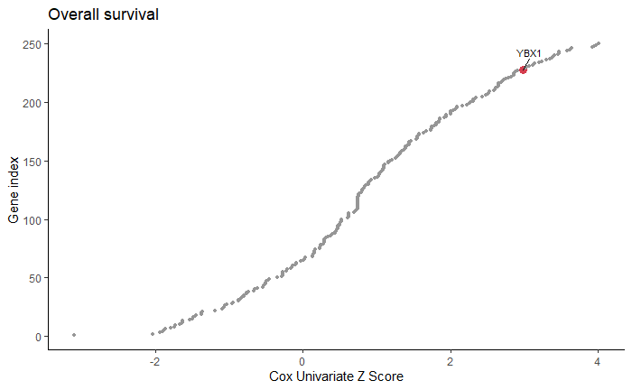

```r
##########################################################################################
esHitsPlot = esHitsGenes %>%
  arrange(coxz) %>%
  mutate(index = seq(1,nrow(esHitsGenes),1))
esHitsPlot$pText = ifelse(esHitsPlot$symbol == 'YBX1', esHitsPlot$symbol, '')
esHitsPlot$pSize = ifelse(esHitsPlot$symbol == 'YBX1', 3, 1)
esHitsPlot$pColors = ifelse(esHitsPlot$symbol == 'YBX1', brewer.pal(8,'Spectral')[1], brewer.pal(8,'Greys')[5])
#esHitsPlot$pText = ifelse(esHitsPlot$coxz >= 2.5, esHitsPlot$symbol, '')
##
ggplot(esHitsPlot, aes(coxz, index)) +
  geom_point(size = esHitsPlot$pSize, color = esHitsPlot$pColors) +
  geom_text_repel(label = esHitsPlot$pText, size = 3, segment.size = 0.25) +
  labs(x = 'Cox Univariate Z Score', y = 'Gene index', title = 'Overall survival') +
  theme_classic()
ggsave(paste(baseWorkspace, '/microarray20200604_ewingSarcomaAllSets/scatter_savolaOverallSurvivalTop250.pdf', sep = ''),
       width = 3, height = 4, useDingbats = FALSE)
```

Now we can make a nice plot for YB-1 survival.

```r
##########################################################################################
expressionData = savolaExpression
phenotypeData = savolaPhenotype
geneOfInterest = 'YBX1'
survivalAnalysis(geneOfInterest, expressionData, phenotypeData, survivalPlot = TRUE, survivalData = TRUE)
```

[output not shown]

```
Performing analysis for YBX1
```

```
Call: survfit(formula = Surv(ovs, status) ~ geneLevel, data = geneSurvivalInput)

   31 observations deleted due to missingness
                n events median 0.95LCL 0.95UCL
geneLevel=low  17      5     NA    61.5      NA
geneLevel=high 16     12   41.6    16.6      NA
geneLevelhigh
     2.980595
```

Ignore other data sets for now until we see if we can get that really large cohort from Delattre.

```r
##########################################################################################
expressionData = volchenExpressionB
phenotypeData = volchenPhenotypeB
geneOfInterest = as.list(esHitsGenes$symbol)
coxZScores = lapply(geneOfInterest, survivalAnalysis, expressionData = expressionData, phenotypeData = phenotypeData, plot = FALSE)
esHitsGenes$coxz = unlist(coxZScores)
```

Now we can make a plot for these scores.

```r
##########################################################################################
esHitsPlot = esHitsGenes %>%
  arrange(coxz) %>%
  mutate(index = seq(1,nrow(esHitsGenes),1))
#esHitsPlot$pText = ifelse(esHitsPlot$symbol == 'YBX1', esHitsPlot$symbol, '')
esHitsPlot$pText = ifelse(esHitsPlot$coxz >= 1, esHitsPlot$symbol, '')
##
ggplot(esHitsPlot, aes(coxz, index)) +
  geom_point(size = 1) +
  geom_text_repel(label = esHitsPlot$pText, size = 3, segment.size = 0.25) +
  labs(x = 'Cox univariate Z score', y = 'Gene index', title = 'Overall survival') +
  theme_classic()
ggsave(paste(baseRepository, '/microarray20200604_ewingSarcomaAllSets/scatter_volchenboumOverallSurvivalTop250.pdf', sep = ''),
       width = 4, height = 4, useDingbats = FALSE)
```

[output not shown]

[session information not shown]